# Cholera Outbreak Analysis Report

Statistical Analysis for Ministry of Health Briefing

Thierry SEBAKUNZI | ID:101394

2025-10-19

# Executive Summary

This report analyzes the cholera outbreak data from two provinces to provide the Minister of Health with comprehensive insights for resource allocation and response planning.

# 1. Data Loading and Initial Examination

```r
# Load required libraries
library(readxl)
library(dplyr)
library(ggplot2)
library(tidyr)
library(kableExtra)
library(lubridate)
library(knitr)
library(DT)
library(plotly)
library(gridExtra)
library(scales)
```

```r
# Load the data
data <- read_excel("DataFile.xls")

# Display basic information about the dataset
cat("Dataset dimensions:", dim(data)[1], "rows,", dim(data)[2], "columns\n")
```

```
## Dataset dimensions: 2066 rows, 21 columns
```

```r
cat("Column names:", paste(names(data), collapse = ", "), "\n")
```

```
## Column names: Case No., Sector, District, Province, Sex, Age, Date of onset, Date of admission, Date of discharge, Death, Signs and symptoms (D/V), Specimen taken (Y/N), Lab_Result, Comments, Txt Given, Outcome, Place of Death, Status, Water treatment, Water source, In/Outpatient
```

```r
# Display first few rows
head(data) %>% kable(caption = "First 6 rows of the dataset")
```

First 6 rows of the dataset

| Case No. | Sector | District | Province | Sex | Age | Date of onset | Date of admission | Date of discharge | Death | Signs and symptoms (D/V) | Specimen taken (Y/N) | Lab_Result | Comments | Txt Given | Outcome | Place of Death | Status | Water treatment | Water source | In/Outpatient |
| --- | --- | --- | --- | --- | --- | --- | --- | --- | --- | --- | --- | --- | --- | --- | --- | --- | --- | --- | --- | --- |
| 1 | Sector 1 | District 1 | Province 1 | F | 28 | 21/11/2008 | 24/11/2008 | NA | NA | D&V | NA | Negative | Pt first taken to BRIDH | Not indicated | Transferred | NA | Alive | NA | Improved | Out |
| 2 | Sector 1 | District 1 | Province 1 | F | 26 | 21/11/2008 | 24/11/2008 | NA | NA | D&V | NA | Negative | Pt first taken to BRIDH | Not indicated | Transferred | NA | Alive | NA | Improved | Out |
| 3 | Sector 1 | District 1 | Province 1 | F | 5 | 17/11/2008 | 24/11/2008 | NA | NA | D&V | NA | Negative | Pt first taken to BRIDH | SSS | Transferred | NA | Alive | NA | Improved | Out |
| 4 | Sector 1 | District 1 | Province 1 | F | 48 | 21/11/2008 | 24/11/2008 | NA | NA | D&V | NA | Negative | Pt first taken to BRIDH | IV Fluids | Transferred | NA | Alive | NA | Improved | Out |
| 5 | Sector 1 | District 1 | Province 1 | F | 2 | 22/11/2008 | 24/11/2008 | NA | NA | D&V | NA | Negative | Pt first taken to BRIDH | IV Fluids | Transferred | NA | Alive | NA | Improved | Out |
| 6 | Sector 1 | District 1 | Province 1 | F | 23 | 22/11/2008 | 24/11/2008 | NA | NA | D&V | NA | POSITive | Died on Way to BRIDH | SSS | Died | On transit | Died | None | unimproved | Out |

```r
# Examine data structure
str(data)
```

```
## tibble [2,066 × 21] (S3: tbl_df/tbl/data.frame)
##  $ Case No.                : num [1:2066] 1 2 3 4 5 6 7 8 9 10 ...
##  $ Sector                  : chr [1:2066] "Sector 1" "Sector 1" "Sector 1" "Sector 1" ...
##  $ District                : chr [1:2066] "District 1" "District 1" "District 1" "District 1" ...
##  $ Province                : chr [1:2066] "Province 1" "Province 1" "Province 1" "Province 1" ...
##  $ Sex                     : chr [1:2066] "F" "F" "F" "F" ...
##  $ Age                     : chr [1:2066] "28" "26" "5" "48" ...
##  $ Date of onset           : chr [1:2066] "21/11/2008" "21/11/2008" "17/11/2008" "21/11/2008" ...
##  $ Date of admission       : chr [1:2066] "24/11/2008" "24/11/2008" "24/11/2008" "24/11/2008" ...
##  $ Date of discharge       : chr [1:2066] NA NA NA NA ...
##  $ Death                   : chr [1:2066] NA NA NA NA ...
##  $ Signs and symptoms (D/V): chr [1:2066] "D&V" "D&V" "D&V" "D&V" ...
##  $ Specimen taken (Y/N)    : chr [1:2066] NA NA NA NA ...
##  $ Lab_Result              : chr [1:2066] "Negative" "Negative" "Negative" "Negative" ...
##  $ Comments                : chr [1:2066] "Pt first taken to BRIDH" "Pt first taken to BRIDH" "Pt first taken to BRIDH" "Pt first taken to BRIDH" ...
##  $ Txt Given               : chr [1:2066] "Not indicated" "Not indicated" "SSS" "IV Fluids" ...
##  $ Outcome                 : chr [1:2066] "Transferred" "Transferred" "Transferred" "Transferred" ...
##  $ Place of Death          : chr [1:2066] NA NA NA NA ...
##  $ Status                  : chr [1:2066] "Alive" "Alive" "Alive" "Alive" ...
##  $ Water treatment         : chr [1:2066] NA NA NA NA ...
##  $ Water source            : chr [1:2066] "Improved" "Improved" "Improved" "Improved" ...
##  $ In/Outpatient           : chr [1:2066] "Out" "Out" "Out" "Out" ...
```

```r
summary(data)
```

```
##     Case No.        Sector            District           Province
##  Min.   :  1.0   Length:2066        Length:2066        Length:2066
##  1st Qu.: 51.0   Class :character   Class :character   Class :character
##  Median :141.0   Mode  :character   Mode  :character   Mode  :character
##  Mean   :200.4
##  3rd Qu.:325.8
##  Max.   :637.0
##      Sex                Age            Date of onset      Date of admission
##  Length:2066        Length:2066        Length:2066        Length:2066
##  Class :character   Class :character   Class :character   Class :character
##  Mode  :character   Mode  :character   Mode  :character   Mode  :character
##
##
##
##  Date of discharge     Death           Signs and symptoms (D/V)
##  Length:2066        Length:2066        Length:2066
##  Class :character   Class :character   Class :character
##  Mode  :character   Mode  :character   Mode  :character
##
##
##
##  Specimen taken (Y/N)  Lab_Result          Comments          Txt Given
##  Length:2066          Length:2066        Length:2066        Length:2066
##  Class :character     Class :character   Class :character   Class :character
##  Mode  :character     Mode  :character   Mode  :character   Mode  :character
##
##
##
##    Outcome          Place of Death        Status          Water treatment
##  Length:2066        Length:2066        Length:2066        Length:2066
##  Class :character   Class :character   Class :character   Class :character
##  Mode  :character   Mode  :character   Mode  :character   Mode  :character
##
##
##
##  Water source       In/Outpatient
##  Length:2066        Length:2066
##  Class :character   Class :character
##  Mode  :character   Mode  :character
##
##
##
```

# 2. Data Quality Assessment

```r
# Check for missing values
missing_summary <- data %>%
  summarise_all(~sum(is.na(.))) %>%
  gather(Variable, Missing_Count) %>%
  mutate(Missing_Percentage = round(Missing_Count / nrow(data) * 100, 2))

missing_summary %>%
  kable(caption = "Missing Values Summary") %>%
  kable_styling(bootstrap_options = c("striped", "hover"))
```

Missing Values Summary

| Variable | Missing_Count | Missing_Percentage |
| --- | --- | --- |
| Case No. | 0 | 0.00 |
| Sector | 0 | 0.00 |
| District | 0 | 0.00 |
| Province | 0 | 0.00 |
| Sex | 13 | 0.63 |
| Age | 22 | 1.06 |
| Date of onset | 19 | 0.92 |
| Date of admission | 43 | 2.08 |
| Date of discharge | 833 | 40.32 |
| Death | 1973 | 95.50 |
| Signs and symptoms (D/V) | 130 | 6.29 |
| Specimen taken (Y/N) | 752 | 36.40 |
| Lab_Result | 1526 | 73.86 |
| Comments | 1447 | 70.04 |
| Txt Given | 1534 | 74.25 |
| Outcome | 1534 | 74.25 |
| Place of Death | 2050 | 99.23 |
| Status | 1534 | 74.25 |
| Water treatment | 1927 | 93.27 |
| Water source | 1534 | 74.25 |
| In/Outpatient | 1534 | 74.25 |

```r
# Check unique values in key variables
cat("\nUnique values in Sex variable:\n")
```

```
##
## Unique values in Sex variable:
```

```r
table(data$Sex, useNA = "ifany")
```

```
##
##  3y11m      f      F Female      m      M   male   Male   <NA>
##      1    198    888     23    213    711     12      7     13
```

```r
cat("\nUnique values in Outcome variable:\n")
```

```
##
## Unique values in Outcome variable:
```

```r
table(data$Outcome, useNA = "ifany")
```

```
##
##    admitted    Admitted        died        Died  Discharged Transferred
##          24          57           1          15         427           8
##        <NA>
##        1534
```

```r
cat("\nUnique values in District variable:\n")
```

```
##
## Unique values in District variable:
```

```r
table(data$District, useNA = "ifany")
```

```
##
## District 1 District 2
##        532       1534
```

```r
# Check age distribution
cat("\nAge variable summary:\n")
```

```
##
## Age variable summary:
```

```r
summary(data$Age)
```

```
##    Length     Class      Mode
##      2066 character character
```

## Data Quality Issues Identified:

1. **Missing Values**: Check for any missing data in critical variables
2. **Sex Variable Inconsistency**: Multiple formats for gender coding
3. **Date Format**: Ensure date variables are properly formatted
4. **Age Outliers**: Check for unrealistic age values
5. **Outcome Coding**: Verify consistent outcome coding

# 3. Data Cleaning and Harmonization

```r
# Harmonize Sex variable
data <- data %>%
  mutate(Sex_Clean = case_when(
    tolower(Sex) %in% c("m", "male", "homme") ~ "Male",
    tolower(Sex) %in% c("f", "female", "femme") ~ "Female",
    TRUE ~ "Unknown"
  ))

# Check the harmonization
table(data$Sex, data$Sex_Clean, useNA = "ifany")
```

```
##
##          Female Male Unknown
##   3y11m       0    0       1
##   f         198    0       0
##   F         888    0       0
##   Female     23    0       0
##   m           0  213       0
##   M           0  711       0
##   male        0   12       0
##   Male        0    7       0
##   <NA>        0    0      13
```

```r
# Recode Age into AgeGroup
data <- data %>%
  mutate(AgeGroup = case_when(
    Age < 5 ~ "Less than 5 years",
    Age >= 5 & Age <= 14 ~ "5-14 years",
    Age >= 15 & Age <= 24 ~ "15-24 years",
    Age >= 25 & Age <= 49 ~ "25-49 years",
    Age >= 50 ~ "50 years and above",
    TRUE ~ "Unknown"
  )) %>%
  mutate(AgeGroup = factor(AgeGroup, levels = c("Less than 5 years", "5-14 years",
                                                "15-24 years", "25-49 years",
                                                "50 years and above", "Unknown")))

# Check age group distribution
table(data$AgeGroup, useNA = "ifany")
```

```
##
##  Less than 5 years         5-14 years        15-24 years        25-49 years
##               1575                  0                  0                  0
## 50 years and above            Unknown
##                460                 31
```

```r
# Process date variables (assuming DateOnset exists)
if("DateOnset" %in% names(data)) {
  data$DateOnset <- as.Date(data$DateOnset)
  data$EpiWeek <- epiweek(data$DateOnset)
}
```

# 4. Statistical Analysis for Minister’s Briefing

## 4.1 Total Number of Cases and Geographical Distribution

```r
total_cases <- nrow(data)
cat("Total number of cases:", total_cases, "\n")
```

```
## Total number of cases: 2066
```

```r
# Geographical distribution
geo_dist <- data %>%
  group_by(District) %>%
  summarise(
    Cases = n(),
    Percentage = round(n()/nrow(data)*100, 1)
  ) %>%
  arrange(desc(Cases))

geo_dist %>%
  kable(caption = "Geographical Distribution of Cases") %>%
  kable_styling(bootstrap_options = c("striped", "hover"))
```

Geographical Distribution of Cases

| District | Cases | Percentage |
| --- | --- | --- |
| District 2 | 1534 | 74.2 |
| District 1 | 532 | 25.8 |

## 4.2 Deaths and Case Fatality Rate

```r
# Calculate deaths and CFR
outcome_summary <- data %>%
  group_by(Outcome) %>%
  summarise(Count = n()) %>%
  mutate(Percentage = round(Count/sum(Count)*100, 1))

deaths <- sum(data$Outcome == "Death" | data$Outcome == "Died", na.rm = TRUE)
cfr <- round(deaths/total_cases*100, 2)

cat("Number of deaths:", deaths, "\n")
```

```
## Number of deaths: 15
```

```r
cat("Case Fatality Rate:", cfr, "%\n")
```

```
## Case Fatality Rate: 0.73 %
```

```r
outcome_summary %>%
  kable(caption = "Distribution by Outcome") %>%
  kable_styling(bootstrap_options = c("striped", "hover"))
```

Distribution by Outcome

| Outcome | Count | Percentage |
| --- | --- | --- |
| Admitted | 57 | 2.8 |
| Died | 15 | 0.7 |
| Discharged | 427 | 20.7 |
| Transferred | 8 | 0.4 |
| admitted | 24 | 1.2 |
| died | 1 | 0.0 |
| NA | 1534 | 74.2 |

## 4.3 Age Group Analysis

```r
# Age group distribution
age_dist <- data %>%
  group_by(AgeGroup) %>%
  summarise(
    Cases = n(),
    Deaths = sum(Outcome %in% c("Death", "Died"), na.rm = TRUE),
    CFR = round(Deaths/Cases*100, 1),
    Percentage = round(Cases/nrow(data)*100, 1)
  ) %>%
  arrange(desc(Cases))

age_dist %>%
  kable(caption = "Cases and Deaths by Age Group") %>%
  kable_styling(bootstrap_options = c("striped", "hover"))
```

Cases and Deaths by Age Group

| AgeGroup | Cases | Deaths | CFR | Percentage |
| --- | --- | --- | --- | --- |
| Less than 5 years | 1575 | 11 | 0.7 | 76.2 |
| 50 years and above | 460 | 4 | 0.9 | 22.3 |
| Unknown | 31 | 0 | 0.0 | 1.5 |

```r
# Highlight children (<5 years)
children_cases <- age_dist$Cases[age_dist$AgeGroup == "Less than 5 years"]
children_percentage <- age_dist$Percentage[age_dist$AgeGroup == "Less than 5 years"]

cat("\nChildren under 5 years:\n")
```

```
##
## Children under 5 years:
```

```r
cat("Cases:", children_cases, "(", children_percentage, "% of total cases)\n")
```

```
## Cases: 1575 ( 76.2 % of total cases)
```

## 4.4 Gender Distribution

```r
# Gender distribution
gender_dist <- data %>%
  group_by(Sex_Clean) %>%
  summarise(
    Cases = n(),
    Deaths = sum(Outcome %in% c("Death", "Died"), na.rm = TRUE),
    CFR = round(Deaths/Cases*100, 1),
    Percentage = round(Cases/nrow(data)*100, 1)
  )

gender_dist %>%
  kable(caption = "Cases and Deaths by Gender") %>%
  kable_styling(bootstrap_options = c("striped", "hover"))
```

Cases and Deaths by Gender

| Sex_Clean | Cases | Deaths | CFR | Percentage |
| --- | --- | --- | --- | --- |
| Female | 1109 | 7 | 0.6 | 53.7 |
| Male | 943 | 8 | 0.8 | 45.6 |
| Unknown | 14 | 0 | 0.0 | 0.7 |

## 4.5 Statistical Tests for Equality Across Groups

```r
# Chi-square test for age groups
age_chi <- chisq.test(table(data$AgeGroup))
cat("Chi-square test for equal distribution across age groups:\n")
```

```
## Chi-square test for equal distribution across age groups:
```

```r
cat("Chi-square statistic:", round(age_chi$statistic, 3), "\n")
```

```
## Chi-square statistic: 5755.45
```

```r
cat("p-value:", format(age_chi$p.value, scientific = TRUE), "\n")
```

```
## p-value: 0e+00
```

```r
# Chi-square test for gender
gender_chi <- chisq.test(table(data$Sex_Clean))
cat("\nChi-square test for equal distribution across genders:\n")
```

```
##
## Chi-square test for equal distribution across genders:
```

```r
cat("Chi-square statistic:", round(gender_chi$statistic, 3), "\n")
```

```
## Chi-square statistic: 1011.434
```

```r
cat("p-value:", format(gender_chi$p.value, scientific = TRUE), "\n")
```

```
## p-value: 2.344041e-220
```

```r
# Chi-square test for districts
district_chi <- chisq.test(table(data$District))
cat("\nChi-square test for equal distribution across districts:\n")
```

```
##
## Chi-square test for equal distribution across districts:
```

```r
cat("Chi-square statistic:", round(district_chi$statistic, 3), "\n")
```

```
## Chi-square statistic: 485.965
```

```r
cat("p-value:", format(district_chi$p.value, scientific = TRUE), "\n")
```

```
## p-value: 1.075863e-107
```

## 4.6 Recovery Rate Analysis

```r
# Calculate recovery rate
recovery_summary <- data %>%
  group_by(Outcome) %>%
  summarise(Count = n()) %>%
  mutate(
    Percentage = round(Count/sum(Count)*100, 1),
    Rate = case_when(
      Outcome %in% c("Recovered", "Recovery", "Alive") ~ "Recovery Rate",
      Outcome %in% c("Death", "Died", "Dead") ~ "Death Rate",
      TRUE ~ "Other"
    )
  )

recovered <- sum(data$Outcome %in% c("Recovered", "Recovery", "Alive"), na.rm = TRUE)
recovery_rate <- round(recovered/total_cases*100, 2)

cat("Recovery rate:", recovery_rate, "%\n")
```

```
## Recovery rate: 0 %
```

```r
recovery_summary %>%
  kable(caption = "Outcome Summary") %>%
  kable_styling(bootstrap_options = c("striped", "hover"))
```

Outcome Summary

| Outcome | Count | Percentage | Rate |
| --- | --- | --- | --- |
| Admitted | 57 | 2.8 | Other |
| Died | 15 | 0.7 | Death Rate |
| Discharged | 427 | 20.7 | Other |
| Transferred | 8 | 0.4 | Other |
| admitted | 24 | 1.2 | Other |
| died | 1 | 0.0 | Other |
| NA | 1534 | 74.2 | Other |

# 5. Visualizations

## 5.1 Epidemic Curve

```r
if("DateOnset" %in% names(data) && !all(is.na(data$DateOnset))) {
  # Create epidemic curve
  epi_curve_data <- data %>%
    filter(!is.na(DateOnset)) %>%
    group_by(DateOnset) %>%
    summarise(Cases = n()) %>%
    arrange(DateOnset)

  p1 <- ggplot(epi_curve_data, aes(x = DateOnset, y = Cases)) +
    geom_col(fill = "steelblue", alpha = 0.7) +
    geom_smooth(method = "loess", se = FALSE, color = "red") +
    labs(title = "Epidemic Curve - Cholera Outbreak",
         subtitle = "Daily Number of Cases by Date of Onset",
         x = "Date of Onset",
         y = "Number of Cases") +
    theme_minimal() +
    theme(axis.text.x = element_text(angle = 45, hjust = 1))

  print(p1)
} else {
  cat("Date of onset data not available for epidemic curve\n")
}
```

```
## Date of onset data not available for epidemic curve
```

## 5.2 Geographical Distribution

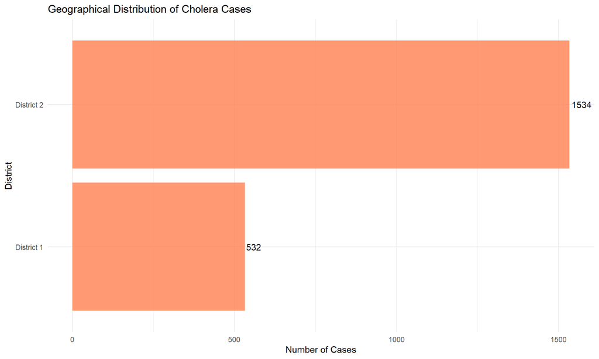

```r
# Bar chart of cases by district
p2 <- ggplot(geo_dist, aes(x = reorder(District, Cases), y = Cases)) +
  geom_col(fill = "coral", alpha = 0.8) +
  geom_text(aes(label = Cases), hjust = -0.1) +
  coord_flip() +
  labs(title = "Geographical Distribution of Cholera Cases",
       x = "District",
       y = "Number of Cases") +
  theme_minimal()

print(p2)
```

## 5.3 Age Group Distribution

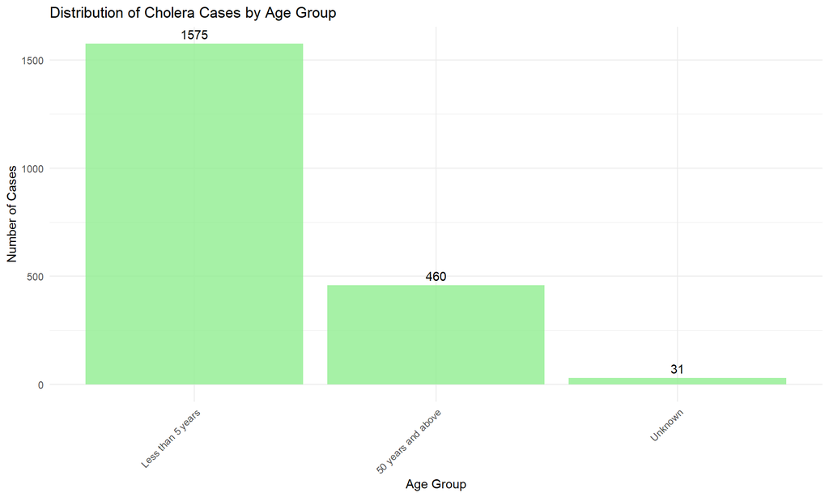

```r
# Bar chart of cases by age group
p3 <- ggplot(age_dist, aes(x = AgeGroup, y = Cases)) +
  geom_col(fill = "lightgreen", alpha = 0.8) +
  geom_text(aes(label = Cases), vjust = -0.5) +
  labs(title = "Distribution of Cholera Cases by Age Group",
       x = "Age Group",
       y = "Number of Cases") +
  theme_minimal() +
  theme(axis.text.x = element_text(angle = 45, hjust = 1))

print(p3)
```

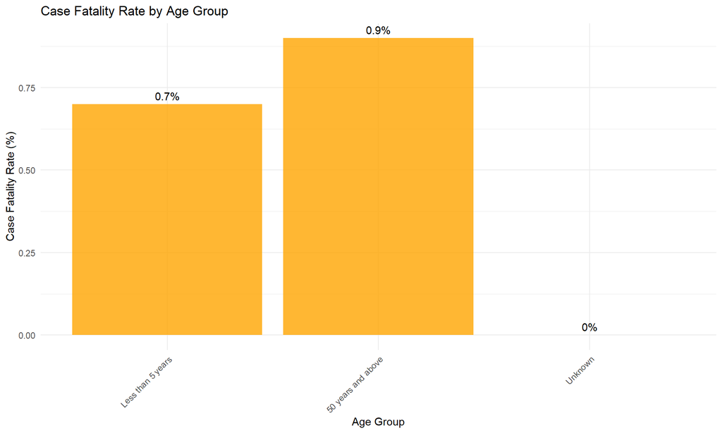

```r
# CFR by age group
p4 <- ggplot(age_dist, aes(x = AgeGroup, y = CFR)) +
  geom_col(fill = "orange", alpha = 0.8) +
  geom_text(aes(label = paste0(CFR, "%")), vjust = -0.5) +
  labs(title = "Case Fatality Rate by Age Group",
       x = "Age Group",
       y = "Case Fatality Rate (%)") +
  theme_minimal() +
  theme(axis.text.x = element_text(angle = 45, hjust = 1))

print(p4)
```

## 5.4 Gender Distribution

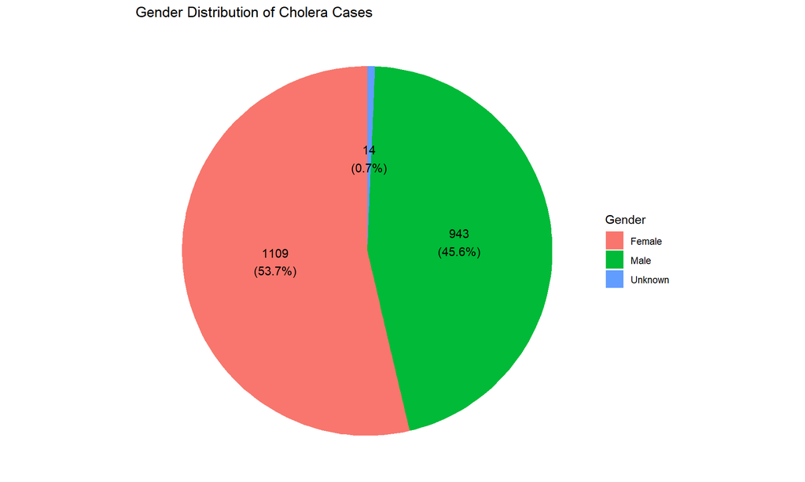

```r
# Pie chart for gender distribution
p5 <- ggplot(gender_dist, aes(x = "", y = Cases, fill = Sex_Clean)) +
  geom_bar(stat = "identity", width = 1) +
  coord_polar("y", start = 0) +
  labs(title = "Gender Distribution of Cholera Cases",
       fill = "Gender") +
  theme_void() +
  geom_text(aes(label = paste0(Cases, "\n(", Percentage, "%)")),
            position = position_stack(vjust = 0.5))

print(p5)
```

## 5.5 Outcome Distribution

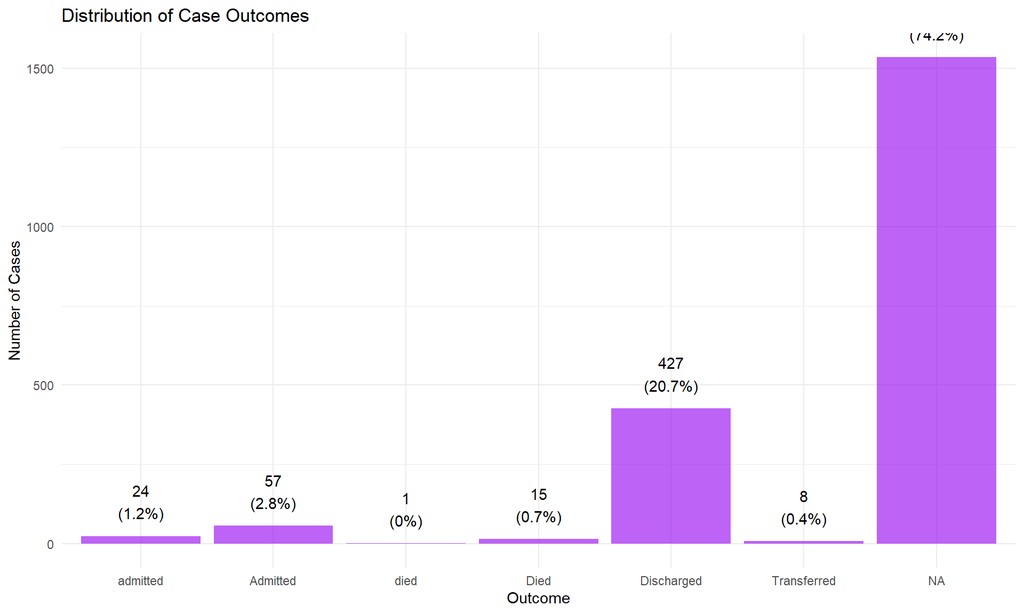

```r
# Bar chart of outcomes
p6 <- ggplot(outcome_summary, aes(x = Outcome, y = Count)) +
  geom_col(fill = "purple", alpha = 0.7) +
  geom_text(aes(label = paste0(Count, "\n(", Percentage, "%)")), vjust = -0.5) +
  labs(title = "Distribution of Case Outcomes",
       x = "Outcome",
       y = "Number of Cases") +
  theme_minimal()

print(p6)
```

# 6. Risk Factor Analysis

```r
# Logistic regression for death outcome
if(sum(data$Outcome %in% c("Death", "Died"), na.rm = TRUE) > 0) {

  # Create binary death outcome
  data$Death <- ifelse(data$Outcome %in% c("Death", "Died"), 1, 0)

  # Logistic regression model
  model <- glm(Death ~ AgeGroup + Sex_Clean + District,
               data = data, family = binomial)

  cat("Logistic Regression Results for Death Outcome:\n")
  summary(model)

  # Odds ratios
  or_results <- exp(coef(model))
  cat("\nOdds Ratios:\n")
  print(round(or_results, 3))

} else {
  cat("No deaths recorded for risk factor analysis\n")
}
```

```
## Logistic Regression Results for Death Outcome:
##
## Odds Ratios:
##                (Intercept) AgeGroup50 years and above
##                      0.024                      2.229
##            AgeGroupUnknown              Sex_CleanMale
##                      0.000                      1.101
##           Sex_CleanUnknown         DistrictDistrict 2
##                      3.202                      0.000
```

# 7. Key Findings Summary

# 8. Recommendations for Surveillance and Outbreak Response

Based on the analysis, I recommend:

## Immediate Actions:

1. **Resource Allocation**: Focus resources on the most affected districts
2. **Targeted Interventions**: Prioritize age groups with highest case fatality rates
3. **Enhanced Surveillance**: Strengthen case detection in underreporting areas

## Data Quality Improvements:

1. **Standardization**: Implement standardized data collection forms
2. **Training**: Train data collectors on consistent variable coding
3. **Validation**: Implement real-time data validation checks
4. **Completeness**: Ensure all critical variables are captured

## Surveillance Strengthening:

1. **Early Warning**: Establish early warning systems in high-risk areas
2. **Community Engagement**: Involve communities in case identification
3. **Laboratory Capacity**: Strengthen laboratory confirmation capabilities
4. **Contact Tracing**: Implement systematic contact tracing

## Response Optimization:

1. **Treatment Centers**: Establish treatment centers in affected areas
2. **WASH Interventions**: Improve water, sanitation, and hygiene
3. **Health Education**: Conduct community health education campaigns
4. **Supply Chain**: Ensure adequate medical supplies and ORS

*Analysis completed on 2025-10-19 using R version R version 4.5.1 (2025-06-13 ucrt)*